# Griff Volker Final Project

Griff Volker

5/21/23

##Griff Volker Final Project The primary objective of this project is to analyze the population dynamics in Baltimore City over time. We examining the population changes within the city’s census tracts from 2010 to 2021. To accomplish this, we will utilize R for data analysis and export the results into QGIS, to create maps of the population change by taking the difference between 2010 and 2021 population in the data layer’s the attribute table.

In addition to studying population changes, we will investigate the significance of transit and bus stops within Baltimore City. The importance of transit and bus stops allows residents mobility within the city. By understanding how population changes correlate with the presence of bus stops, we can gain insights the census tract we selected.

This project aims to comprehensively assess the population dynamics in Baltimore City, highlighting census tract population changes, transit infrastructure, and the spatial distribution of bus stops.

```r
library(tidycensus)
library(tmap)
library(tidyverse)
```

```r
library(dplyr)
library(ggplot2)
library(ggthemes)
library(tidycensus)
library(tmap)
library(tigris)
library(tmap)
library(tidyverse)
library(sf)
library(tibble)
library(spatstat)
library(spatstat.utils)
library(spatstat.explore)
library(spatstat.geom)
library(maptools)
library(tmap)
library(stars)
census_api_key("3a1aff440e9b2674e8f5b40779f00cf5f8d4fd59", overwrite = TRUE)
```

```
## To install your API key for use in future sessions, run this function with `install = TRUE`.
```

##Getting the variable for total population from the 5 year ACS First, we will get the variable for the total population from the 5 year ACS from 2017-2021

```r
acs_2021 <- load_variables(year = 2021, #the year of our data from 2017-2021
                      dataset = "acs5",
                      cache = TRUE)

#The variable for total population is "B01003_001". We will use this as our starting point for the population of Baltimore City
```

##Obtaining the 5 Year ACS of Baltimore City The total population obtained from the 5 year ACS will be our reference for population change in the city.

```r
balt_population_5_Year_ACS <- get_acs(
  geography = "tract", #we will get the census tracts for Baltimore city
  state = "MD",
  county = "Baltimore City",
  variables = "B01003_001", #total population variable,estimate column is the total population
  year = 2021,
  geometry=TRUE) #year of our data
```

##2010 Decennaial Data for Baltimore City We will obtain the 2010 decennial data to be compared to the 5 year ACS data.

```r
balt_total_population_10 <- get_decennial(
  geography = "tract", #geography
  state = "MD",
  county = "Baltimore City",
  variables = "P001001", #our variable for getting the total population for Baltimore City from the 2010 decennial
  year = 2010
)
```

```
## Using Census Summary File 1
```

##Joining the data In order to complete our population change analysis in QGIS, we will have to join the data together and take out columns we do not need. The population change analysis is completed in QGIS because I am more familiar with calculating differences in QGIS than in R - the population changes per census tract will include negative numbers, which we did not review how to calculate in R this semester.

```r
balt_population_acs_v_decennial_correct <- merge(balt_population_5_Year_ACS,balt_total_population_10, by.x = "GEOID", by.y ="GEOID") #joining the tables together

Balt_pop_acs_V_decennial_correct = subset(balt_population_acs_v_decennial_correct, select = -c(variable.x, moe, NAME.y, variable.y)) #deleting the columns we don't need

#renaming the columns
colnames(Balt_pop_acs_V_decennial_correct)[2]="Name"
colnames(Balt_pop_acs_V_decennial_correct)[3]="Total_Population_2017-2021_5_Year ACS"
colnames(Balt_pop_acs_V_decennial_correct)[4]="Total_Population_2010_Decennial"
```

##Exporting joined tables as a Shapefile We will now export our joined columns as a shape file. Our column “geometry” will produce polygons inside QGIS that we can use to produce maps of our analysis.

```r
st_write(Balt_pop_acs_V_decennial_correct, "Balt_Total_Population_Change5.shp")
```

```
## Writing layer `Balt_Total_Population_Change5' to data source
##   `Balt_Total_Population_Change5.shp' using driver `ESRI Shapefile'
## Writing 198 features with 4 fields and geometry type Multi Polygon.
```

##Population Change Analysis Let’s analyze the Baltimore Census tract population change. After completing the population change analysis in QGIS from taking the difference between the 5 year ACS and the 2010 decennial, you can see that the histogram is not normally distributed around 0. This made it difficult to set the correct symbology and legend in my map of population change.

Let’s make a line graph showing overall population change in Baltimore City.

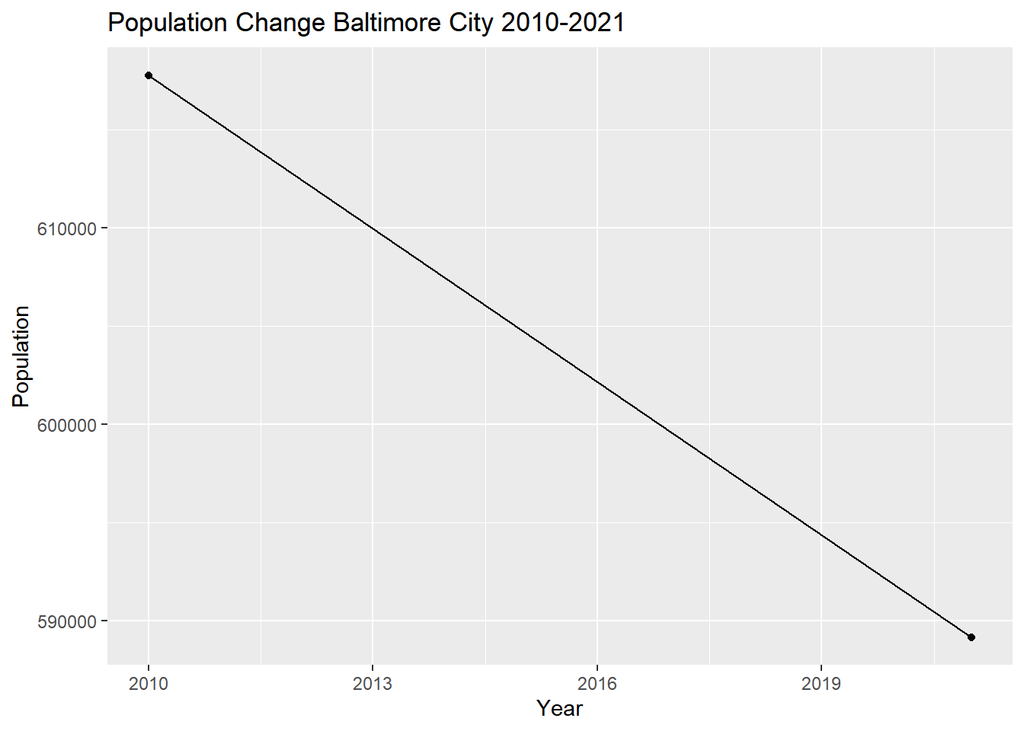

```r
balt_pop_change_csv <- read.csv("C:\\Users\\rules\\Desktop\\UMBC Classes\\GEOG687\\Griff Volker Final Project\\src\\Balt_Total_Population_Change.csv") #reading the CSV of the SHP data we calculated in QGIS

balt_pop_change<-ggplot(balt_pop_change_csv, aes(x=Year, y=Population, group=1)) +
  geom_line()+ ggtitle("Population Change Baltimore City 2010-2021") + #plotting population change over time
  geom_point()

plot(balt_pop_change)
```

Lets make a histogram of the census tracts and how they experienced population change. You will notice that there are negative and positive changes in population and the data is not normally distributed around 0. As stated earlier, this made it difficult to map in QGIS.

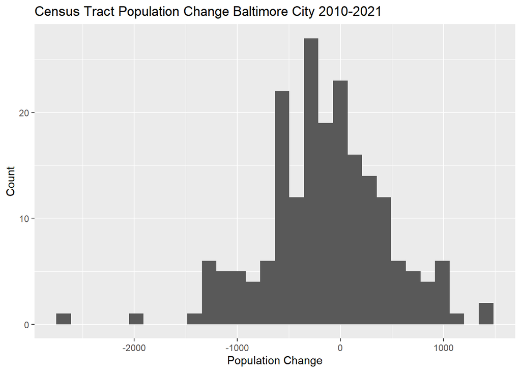

```r
balt_hist <-ggplot (balt_pop_change_csv, aes(x = Pop_Change)) +
  geom_histogram()

balt_hist_export<-balt_hist + ggtitle("Census Tract Population Change Baltimore City 2010-2021") + xlab("Population Change") + ylab("Count")

plot(balt_hist_export)
```

#Further Statistical Analysis of Population Change Let’s do some more analysis of changes in population in Baltimore city

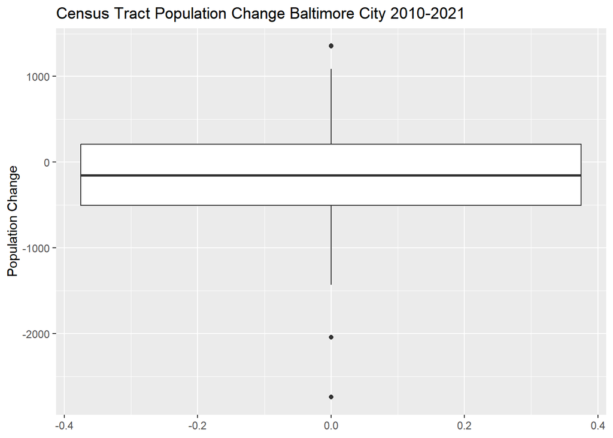

```r
balt_box<-ggplot (balt_pop_change_csv, aes(y = Pop_Change)) +
  geom_boxplot() #making our box plot

balt_box_export<-balt_box + ggtitle("Census Tract Population Change Baltimore City 2010-2021") + ylab("Population Change")

plot(balt_box_export)
```

Let’s continue our analysis with a scatter plot.

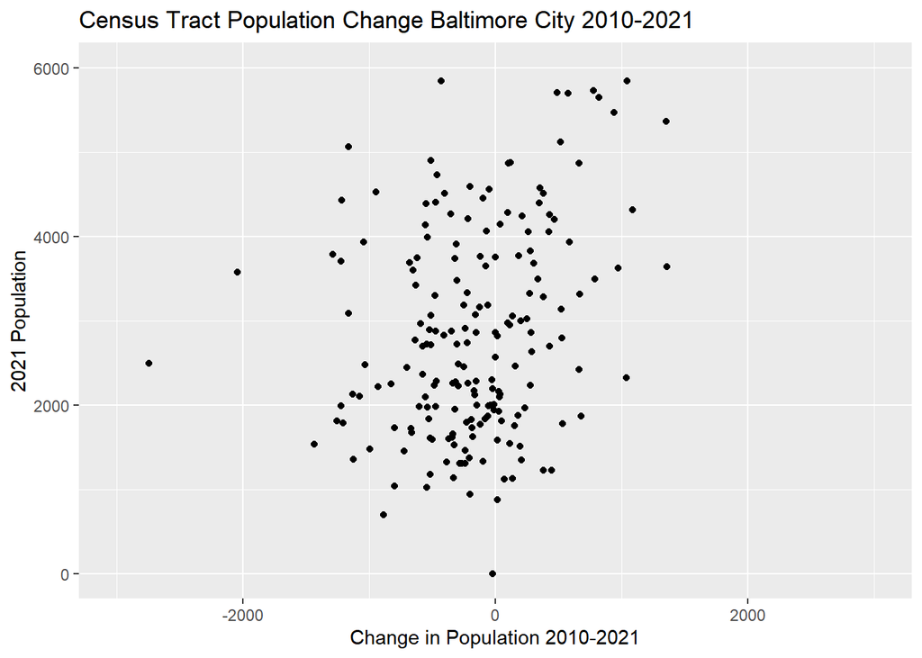

```r
balt_scatter <-ggplot(balt_pop_change_csv, aes(x = Pop_Change, y = Current)) +
  geom_point()

balt_scatter_export<-balt_scatter + ggtitle("Census Tract Population Change Baltimore City 2010-2021") + xlim(-3000, 3000)+ylim(0, 6000) + ylab("2021 Population") + xlab ("Change in Population 2010-2021")

plot(balt_scatter_export)
```

##Using population data in QGIS In my QGIS project, I calculated the population change between 2010 and 2021 and mapped it out by census tract. The goal of this analysis was to find a census tract with a positive population change that we can analyze publicly available point data with. The publicly available point data we have selected for our project are bus stops, downloaded from Overpass Turbo.

Our project objective is to analyze population change by census tract and pick a census tract that we can do further analysis on. This may give insight into why people have moved there.

##Bus Stop Analysis for Census Tract 401 Census Tract 401 is our area we will be researching. This tract was chosen because it had the second largest positive population change from 2010-2021, was one of the largest population tracts, and had the highest number of bus stops in the city. After selecting Census Tract 401 as our census polygon to analyze bus stops using QGIS spatial analysis, we will now perform spatial analysis of the bus stops in that census tract.

```r
balt_census_tract_401<-read_sf("C:\\Users\\rules\\Desktop\\UMBC Classes\\GEOG687\\Griff Volker Final Project\\src\\Balt_Census_401_Correct.gpkg")

bus_stops_401 <- read_csv("C:\\Users\\rules\\Desktop\\UMBC Classes\\GEOG687\\Griff Volker Final Project\\src\\Balt_Bus_Stops_401.csv")
```

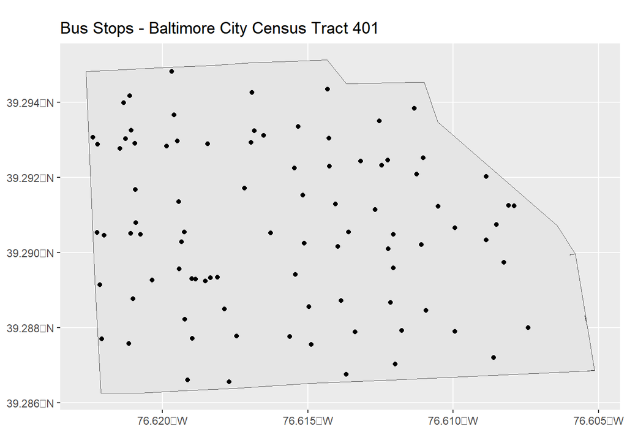

```r
bus_stops_401_4326<-st_as_sf(bus_stops_401,coords=c(x="X",y="Y"), crs=4326)

bus_stops_401_correct<-st_transform(bus_stops_401_4326, crs=3857)

bus_stops_401_plot<-ggplot() + geom_sf(data=balt_census_tract_401) +
geom_sf(data=bus_stops_401_correct) + ggtitle("Bus Stops - Baltimore City Census Tract 401")

plot(bus_stops_401_plot)
```

#Tests to Determine if bus stops are clustered After plotting the bus stop points for Census tract 401, let’s run a KS test to determine if the bus stop data is clustered.

```r
bus_stops_401_ppp  <- as.ppp(bus_stops_401_correct)
ks_bus_401_stops <- cdf.test(bus_stops_401_ppp, "x")
```

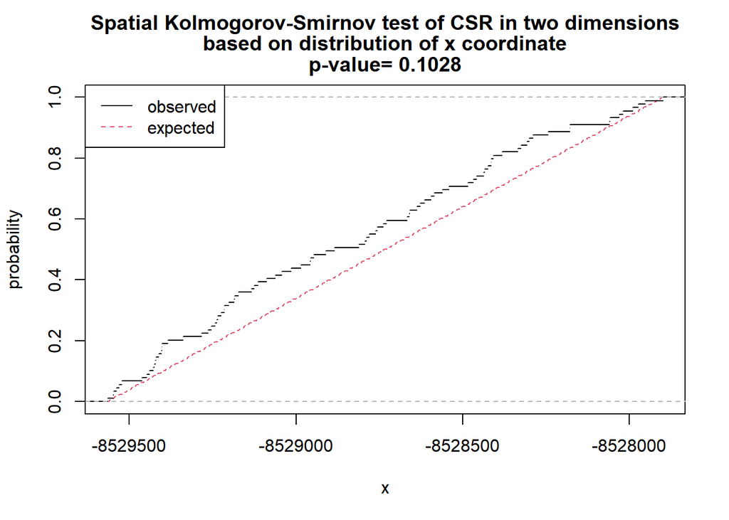

```r
plot(ks_bus_401_stops)
```

##Plotting the Density Covariate Plotting the density covariate of the bus stops in census tracts 401 will give us more information to determine if the data is clustered

```r
ds <- density.ppp(bus_stops_401_ppp)
k_density_Covariate <- cdf.test(bus_stops_401_ppp, ds)
```

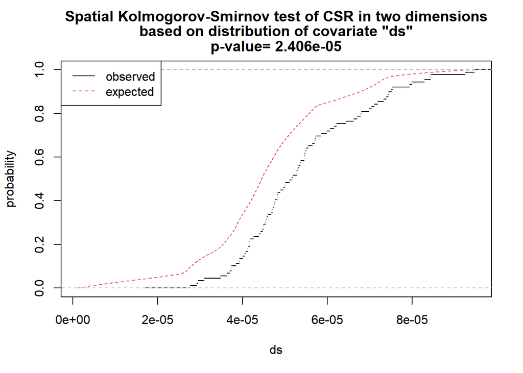

```r
plot(k_density_Covariate)
```